# Exploring the BRFSS data

## Setup

### Load packages

```r
library(ggplot2)
library(dplyr)
```

### Load data

Make sure your data and R Markdown files are in the same directory. When loaded your data file will be called `brfss2013`. Delete this note when before you submit your work.

```r
#load("brfss2013.RData")
load("brfss2013.RData")
```

## Part 1: Data

### Generabizability

I would say that it is possible to make generalizations based on the data but as always, a healthy dose of skepticism is recommended. The main reason for why I believe that it is possible to draw generable conclusions from the data is that the interviewees were selected randomly.

There is a risk of a undercoverage which may lead to a selection bias (more on undercoverage can be found here http://goo.gl/0fjMUn ). This is because some populations may not be represented adequately. As the data is based on telephone interviews, people without telephone are excluded. Furthermore, depending on the time when the phone calls were made may also lead to undercoverage. However, in this case I do not believe that this bias risk is high enough to say that the data is not good enough to draw conclusions from.

### Causality

The data is not based on experiment with randomized assignment, thus any casual inference, should not be drawn from this data! At best, we can calculate correlations, but that is not the same as being able to say anything about causation.

## Part 2: Research questions

The research questions I will focus on the topic of smoking and marital status. I would like to find out tings about smoking habits.

**Research quesion 1:**

The first research question I would like to analyze the association between smoking and marital status. The question is:

- Is it more likely that a randomly drawn person that smokes every day is married or not married?

**Research quesion 2:**

- Of the group daily smokers, are men and women equally represented?
- If I would take a random sample of 10 daily daily smokers, what is the probability that there are 5 or less men in the sample?

**Research quesion 3:**

What does the marital stauts of female daily smokers look like.

## Part 3: Exploratory data analysis

NOTE: Insert code chunks as needed by clicking on the “Insert a new code chunk” button (green button with orange arrow) above. Make sure that your code is visible in the project you submit. Delete this note when before you submit your work.

## Research quesion 1:

### Preparing the data

To understand the questions and the data better I’ll start by analyzing the variables of interest by creating tables and plots. Please note that all the comments are within the R code.

```r
### Analyze and plot the data

## The variable "marital" contains information about marital status
## Check what the variable "marital" looks like by summarizing in table and plot

# Create a table of the marital variable
table(brfss2013$marital)
```

```
##
##                         Married                        Divorced
##                          253329                           70376
##                         Widowed                       Separated
##                           65745                           10662
##                   Never married A member of an unmarried couple
##                           75070                           13173
```

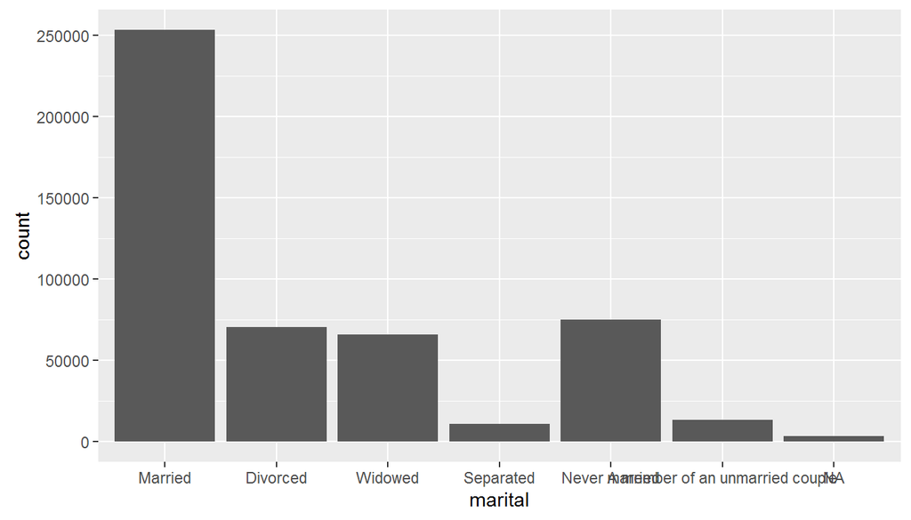

```r
# Interpretation:
# The interviewees are categorized in 6 categories: Married, Divorced, Widowed, Separated, Never married and A member of an unmarried couple

# Plot the data of marital variable to get a more inuitive grasp of the frequenes of the different marital types of marital status
ggplot(data = brfss2013, aes(x = marital)) +
  geom_bar()
```

```r
# Interpretation:
# Clearly most of the interviewees are married.

## The variable "usenow3" contains information about smoking habits
## Check what the variable "usenow3" which contain looks like by summarizing in table and plot

# Create a table of the "usenow3" variable
table(brfss2013$usenow3)
```

```
##
##  Every day  Some days Not at all
##       8767       6867     462123
```

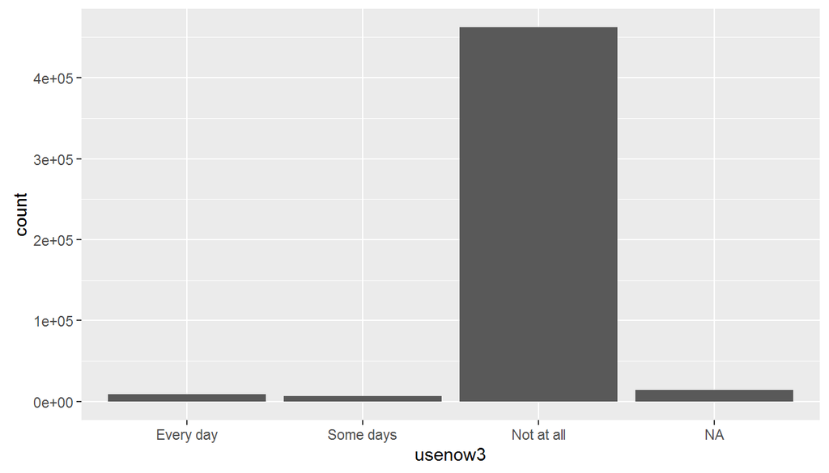

```r
# Plot the data of marital variable
ggplot(data = brfss2013, aes(x = usenow3)) +
  geom_bar()
```

Next, it’s time to prepare the data for the computations by extracting the information of interest by filtering out subsets of the information in the variables `marital` and `usenow3`.

```r
## Prepare for calculations by extracting the information of interest

# Filter out people who are Married
married <- brfss2013 %>%
  filter(marital == "Married")

# Count the observations of the data set married
count(married)
```

```
## Source: local data frame [1 x 1]
##
##        n
##    (int)
## 1 253329
```

```r
# Filter out people that smokes every day
daily_smokers <- brfss2013 %>%
  filter(usenow3=="Every day")

# Count the observations of the data set daily_smokers
count(daily_smokers)
```

```
## Source: local data frame [1 x 1]
##
##       n
##   (int)
## 1  8767
```

```r
# Filter out people that do not smoke every day
non_daily_smokers <- brfss2013 %>%
  filter(usenow3!="Every day")

# Count the observations of the data set non_daily_smokers
count(non_daily_smokers)
```

```
## Source: local data frame [1 x 1]
##
##        n
##    (int)
## 1 468990
```

```r
# Filter out people that do smoke every day and are married
married_smokers <- daily_smokers %>%
  filter(marital=="Married")

# Count the observations of the data set married_smokers
count(married_smokers)
```

```
## Source: local data frame [1 x 1]
##
##       n
##   (int)
## 1  4758
```

Now it’s time to calculate the probabilities.

To start with I’ll calculate the probability that a random person from the data set is a daily smoker, and then I’ll calculate the probability to find a person in the data set that is both a daily smoker and married.

```r
## Calculate probabilities
# Probability that a random person is a daily smoker
p_daily_smoker <- count(daily_smokers) / count(brfss2013)
p_daily_smoker
```

```
##            n
## 1 0.01782726
```

```r
# Probability that a random person is married and a daily smoker
p_married_daily_smoker <- count(married_smokers) / count(brfss2013)
p_married_daily_smoker
```

```
##             n
## 1 0.009675156
```

## Research quesion 2:

Now, I’ll focus on daily smokers and gender and the question wether men and women are equally represented in the daily smoker group.

## Preparing the data

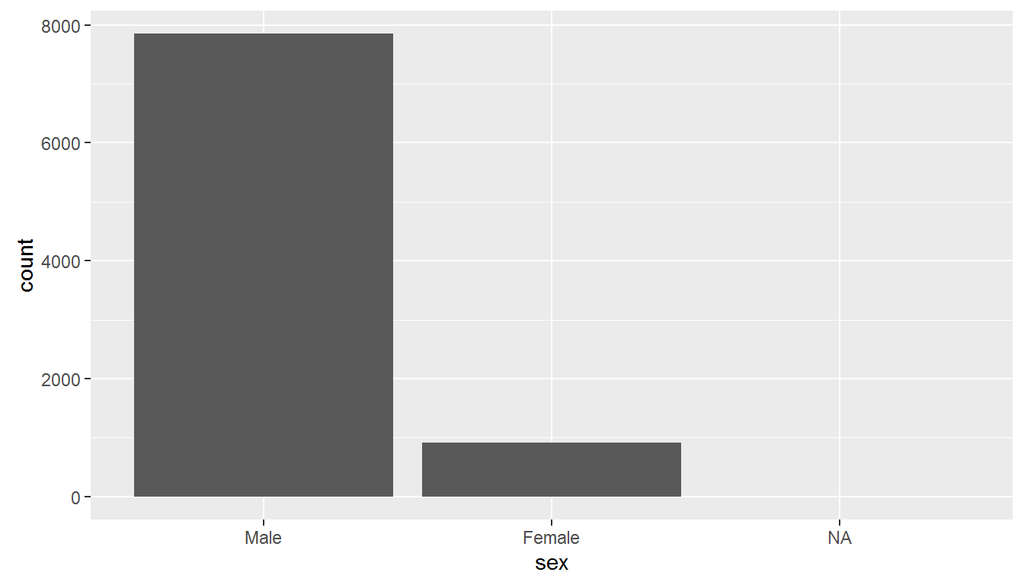

```r
# start with a graphical way of looking at the group of daily smokers and gender
ggplot(data = daily_smokers, aes(x = sex)) +
  geom_bar()
```

It seems like there are predominently men that are daily smokers. To calculate the percentage of the daily smokers that are men:

```r
# Calculate male daily smokers
male_smokers <- daily_smokers %>%
  filter(sex == "Male")

# Calculate percentage men in the group of daily smokers
p_male_smokers <- count(male_smokers)/ count(daily_smokers)
p_male_smokers
```

```
##          n
## 1 0.894947
```

Around 89.5 percent of the daily smokers are men.

The next question was:

*If I would take a random sample of 10 daily daily smokers, what is the probability that there are 5 or less men in the sample?

To calculate this I’ll use the binomial distribution.

#### Check it the conditions are met

Before I do the calculation, however, I must check that the conditions to use the binomial distritubtion are met:

- Is the number of trials fixed? Yes, there are 10 trials and that value is fixed
- Can the outcome be classified as success or not? Yes, the smoker may be a man or not
- Are the trials independent? Yes, the persons in the data set are not likely to dependent

So to summarize the values to use in the calculation:

- The number of successes that we are looking for is 5 or less
- The sample size is 10
- The probability of success (in this case being a man that smokes every day) is 0.895

```r
# o of male daily smokers  = 7846, male smokers = 89.5%. Probability of having at least 3 male daily smokers in a sample size of 10?
sum(dbinom(1:5, size =10, p= 0.895))
```

```
## [1] 0.002040203
```

## Research quesion 3:

### Analyzing the data

We saw earlier that most of the daily smokers were men, but what about the female smokers. How is the marital status distributed for female smokers?

The easiest way to see that is to make a table and a graph. First we have to calculate the number of female daily smokers and female daily smokers that are married.

```r
# Filter out female daily smokers
female_smokers <- daily_smokers %>%
  filter(sex == "Female")

# Filter out married female daily smokers
f_daily_smokers <- female_smokers %>%
  filter(marital == "Married")
```

Then, do the table and a graph

```r
# Table of marital status of female daily smokers
table(female_smokers$marital)
```

```
##
##                         Married                        Divorced
##                             317                             181
##                         Widowed                       Separated
##                             192                              37
##                   Never married A member of an unmarried couple
##                             158                              29
```

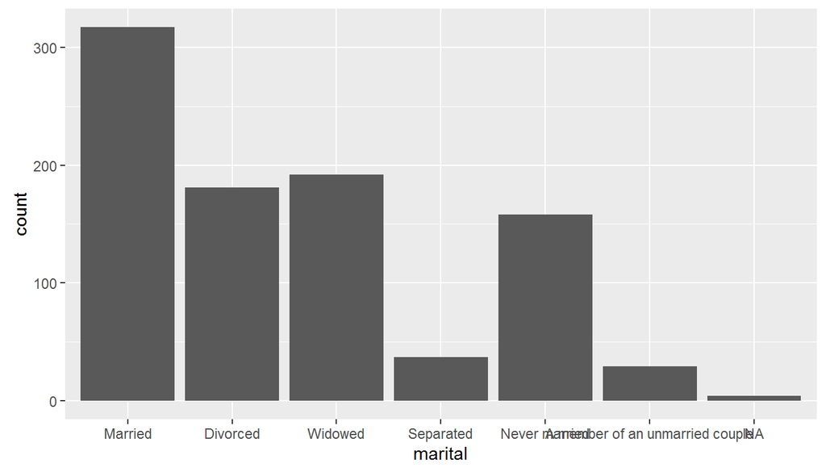

```r
# Plot the data of marital variable
ggplot(data = female_smokers, aes(x = marital)) +
  geom_bar()
```